# DS202 Final Project: Group 4

MyTien Kien, Tanner Dunn

4/21/2021

```r
library(ggplot2)
library(tidyr)
library(dplyr)

main <- readr::read_csv('./excel_files/data.csv')
by_artist <- readr::read_csv('./excel_files/data_by_artist.csv')
by_genre <- readr::read_csv('./excel_files/data_by_genres.csv')
by_year <- readr::read_csv('./excel_files/data_by_year.csv')

main <- drop_na(main)
by_year <- drop_na(by_year)
by_genre <- drop_na(by_genre)
```

## Final Project Questions

**1.** Does a success of a song depend on the date of the song released?

```r
q1 <- by_year %>%
      group_by(year) %>%
      summarize(popularity = mean(popularity)) %>%
      arrange(desc(popularity)) %>%
      head(n = 20)
q1
```

```
## # A tibble: 20 x 2
##     year popularity
##    <dbl>      <dbl>
##  1  2001       50.9
##  2  2004       48.0
##  3  2000       46.3
##  4  2003       45.8
##  5  2002       45.7
##  6  1999       45.2
##  7  1998       44.9
##  8  1997       44.6
##  9  1994       44.4
## 10  1995       44.2
## 11  1996       44.0
## 12  2006       42.7
## 13  2007       42.6
## 14  1992       42.5
## 15  1993       42.3
## 16  2005       42.1
## 17  1990       40.2
## 18  1987       39.0
## 19  1991       39.0
## 20  1988       38.9
```

**2.** Does the popularity of a song depend on the danceability and energy?

```r
q2 <- main %>%
      group_by(popularity) %>%
      select(popularity, artists, name, danceability, energy) %>% arrange(desc(popularity)) %>%
      head(n = 20)
q2
```

```
## # A tibble: 20 x 5
## # Groups:   popularity [7]
##    popularity artists                  name                  danceability energy
##         <dbl> <chr>                    <chr>                        <dbl>  <dbl>
##  1        100 ['Olivia Rodrigo']       drivers license              0.585  0.436
##  2         96 ['24kGoldn', 'iann dior~ Mood (feat. iann dio~        0.7    0.722
##  3         96 ['Ariana Grande']        positions                    0.737  0.802
##  4         95 ['Bad Bunny', 'Jhay Cor~ DÁKITI                       0.731  0.573
##  5         95 ['KAROL G']              BICHOTA                      0.863  0.666
##  6         94 ['Ariana Grande']        34+35                        0.83   0.585
##  7         94 ['CJ']                   Whoopty                      0.711  0.598
##  8         94 ['The Kid LAROI']        WITHOUT YOU                  0.662  0.413
##  9         94 ['Billie Eilish']        Therefore I Am               0.889  0.34
## 10         94 ['Bad Bunny', 'ROSALÍA'] LA NOCHE DE ANOCHE           0.856  0.618
## 11         93 ['Pop Smoke']            What You Know Bout L~        0.709  0.548
## 12         93 ['Tate McRae']           you broke me first           0.642  0.374
## 13         92 ['Cardi B', 'Megan Thee~ WAP (feat. Megan The~        0.935  0.454
## 14         92 ['Lil Nas X']            HOLIDAY                      0.81   0.511
## 15         92 ['Justin Bieber', 'benn~ Lonely (with benny b~        0.631  0.239
## 16         92 ['Justin Bieber']        Anyone                       0.686  0.538
## 17         92 ['Tiësto']               The Business                 0.798  0.62
## 18         92 ['Boza']                 Hecha Pa' Mi                 0.725  0.756
## 19         91 ['Sia']                  Snowman                      0.716  0.512
## 20         91 ['Harry Styles']         Watermelon Sugar             0.548  0.816
```

**3.** What were the five most popular songs in 2020? How do these songs compare to the top five songs in 2010?

```r
#Top 5 for 2020
q3_2020 <- main %>%
      filter(year == 2020) %>%
      select(year, artists, name, popularity) %>%
      arrange(desc(popularity)) %>%
      head(n = 5)
q3_2020
```

```
## # A tibble: 5 x 4
##    year artists                      name                   popularity
##   <dbl> <chr>                        <chr>                       <dbl>
## 1  2020 ['24kGoldn', 'iann dior']    Mood (feat. iann dior)         96
## 2  2020 ['Ariana Grande']            positions                      96
## 3  2020 ['Bad Bunny', 'Jhay Cortez'] DÁKITI                         95
## 4  2020 ['KAROL G']                  BICHOTA                        95
## 5  2020 ['Ariana Grande']            34+35                          94
```

```r
#Top 5 for 2010
q3_2010 <- main %>%
      filter(year == 2010) %>%
      select(year, artists, name, popularity) %>%
      arrange(desc(popularity)) %>%
      head(n = 5)
q3_2010
```

```
## # A tibble: 5 x 4
##    year artists                  name                                 popularity
##   <dbl> <chr>                    <chr>                                     <dbl>
## 1  2010 ['John Lennon', 'Yoko O~ Happy Xmas (War Is Over) - Remaster~         83
## 2  2010 ['Train']                Hey, Soul Sister                             82
## 3  2010 ['Kesha']                TiK ToK                                      81
## 4  2010 ['Eminem', 'Rihanna']    Love The Way You Lie                         81
## 5  2010 ['Miguel']               Sure Thing                                   80
```

**4.** Analyze how song trends (danceability, energy, etc..), changed throughout each year.

```r
q4 <- main %>%
      group_by(year) %>%
      summarise(danceability = mean(danceability),
                acousticness = mean(acousticness),
                energy = mean(energy),
                valence = mean(valence),
                liveness = mean(liveness))

q4
```

```
## # A tibble: 102 x 6
##     year danceability acousticness energy valence liveness
##  * <dbl>        <dbl>        <dbl>  <dbl>   <dbl>    <dbl>
##  1  1920        0.516        0.631  0.419   0.498    0.216
##  2  1921        0.432        0.862  0.241   0.378    0.205
##  3  1922        0.576        0.829  0.226   0.571    0.257
##  4  1923        0.577        0.957  0.262   0.625    0.227
##  5  1924        0.550        0.940  0.344   0.664    0.235
##  6  1925        0.575        0.963  0.278   0.621    0.237
##  7  1926        0.597        0.666  0.211   0.437    0.232
##  8  1927        0.656        0.916  0.268   0.670    0.177
##  9  1928        0.535        0.939  0.209   0.497    0.175
## 10  1929        0.648        0.601  0.242   0.637    0.236
## # ... with 92 more rows
```

I made a dataframe that grouped the averages of danceability, acousticness, energy, valence, and liveness by each year, to see how much has changed from year to year. The following chart will help us visualize the changes.

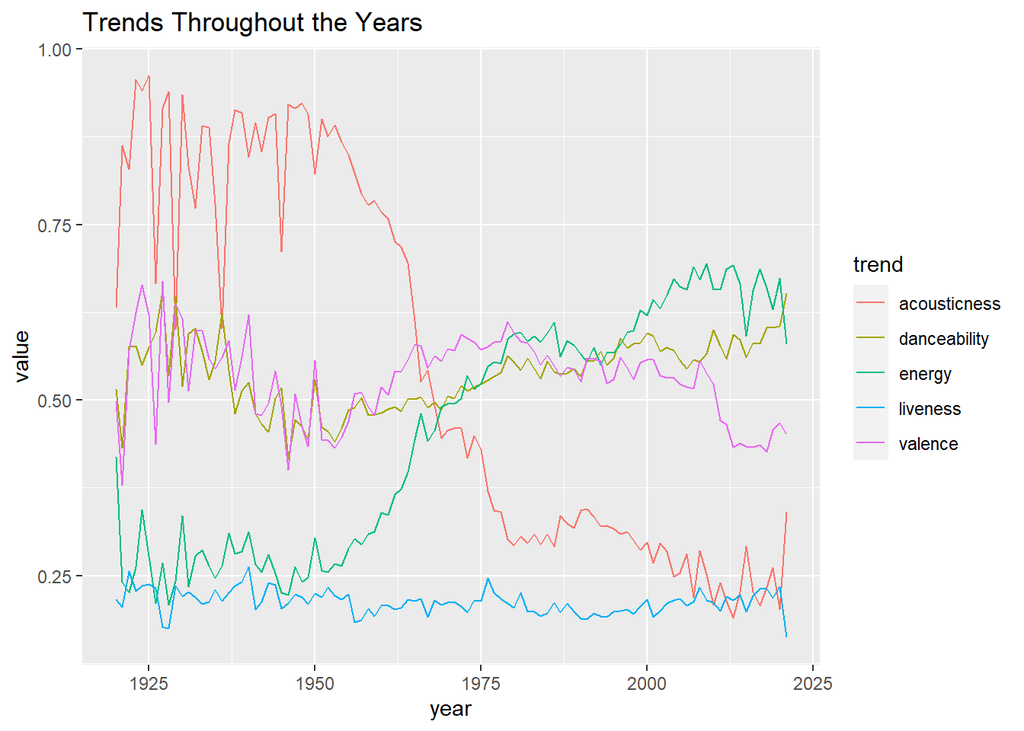

```r
#Plot for song trends
q4 <- q4 %>% pivot_longer(danceability:liveness, names_to = 'trend', values_to = 'value')

q4_plot <- q4 %>%
      ggplot(aes(x = year, y = value, color = trend)) + geom_line() +
      ggtitle("Trends Throughout the Years")

q4_plot
```

According to this chart, the trend that had the most drastic change in the last century is acousticness. Before 1950, acousticness was very popular among songs, until it reached a huge downfall through the years of 1950 to 2000. The trend that grew was the energy level of songs - this lead to it being the highest trend in the past few years. All the other song trends are pretty leveled out, with liveness of a song being the lowest for the majority of the past century.

5. What is the relationship between the tempo of a song and the acousticness?

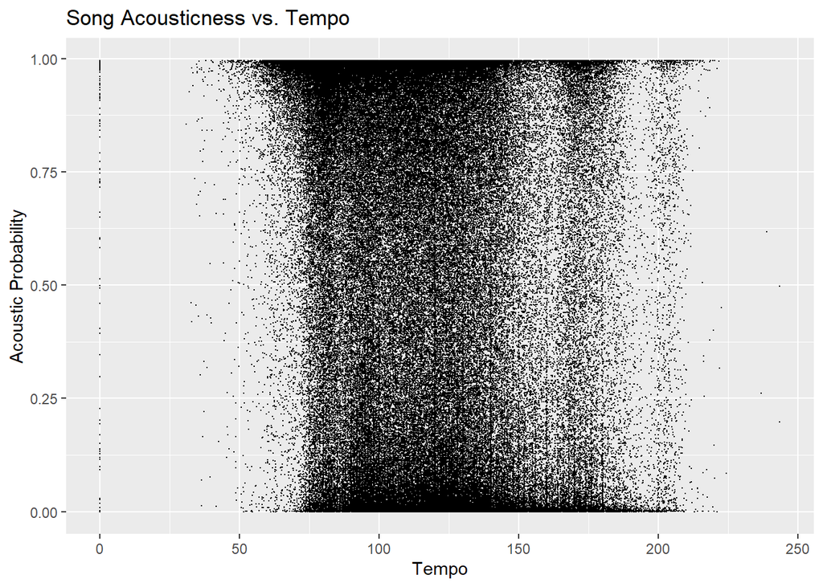

   ```r
   ggplot(main, aes(x=tempo, y=acousticness)) +
     geom_point(size=0.1) +
     labs(title="Song Acousticness vs. Tempo", x="Tempo", y="Acoustic Probability")
   ```

6. Are explicit songs more popular than non-explicit songs?

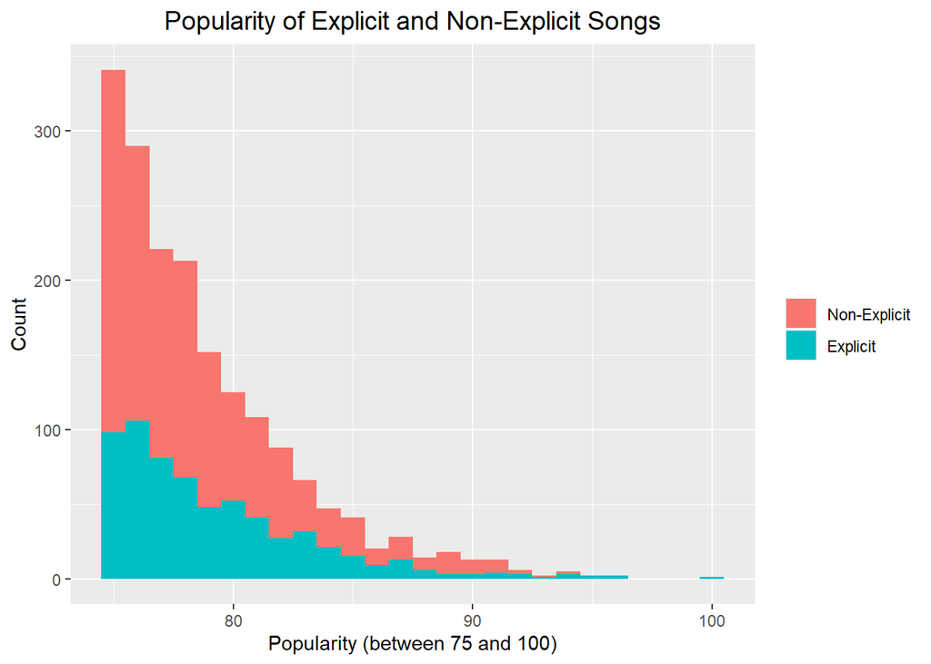

```r
main75 <- subset(main, popularity>=75)
main75$explicit <- as.character(main75$explicit)

ggplot(main75, aes(x=popularity, fill=explicit)) +
      geom_histogram(binwidth = 1) +
      labs(title="Popularity of Explicit and Non-Explicit Songs", x="Popularity (between 75 and 100)", y="Count") +
      theme(plot.title = element_text(size=14, hjust=0.5)) +
      theme(legend.title = element_blank()) +
      scale_fill_discrete(labels = c("Non-Explicit", "Explicit"))
```

**7.** Who are the most popular one hit wonders?

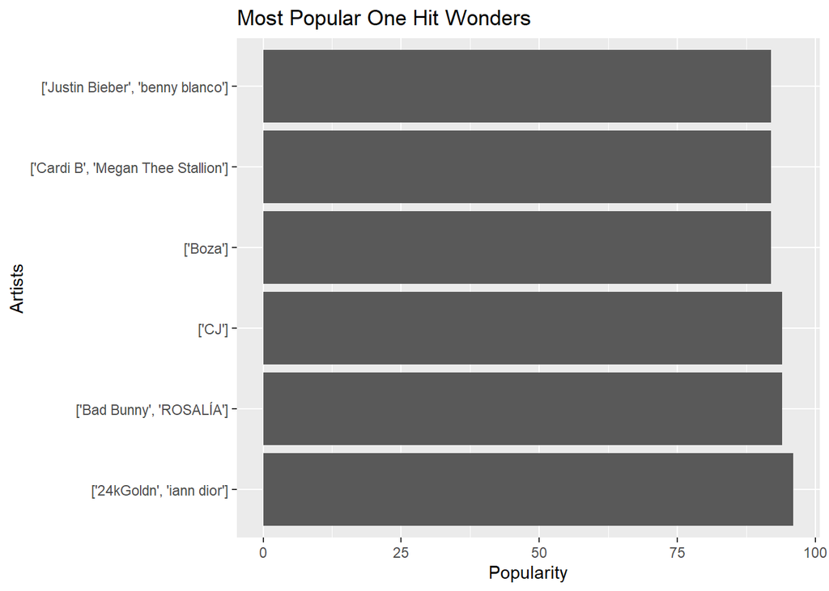

```r
one_hit_wonder <- main %>%
      group_by(artists = artists) %>%
      summarise(Num_track = n(), Popularity = mean(popularity)) %>%
      filter(Num_track == 1) %>%
      top_n(5, wt = Popularity)

ggplot(one_hit_wonder, aes(x = reorder(artists, -Popularity), weight = Popularity)) + geom_bar() + coord_cartesian(ylim=c(75,100)) +
      xlab("Artists") + ylab("Popularity") + ggtitle("Most Popular One Hit Wonders") + coord_flip()
```

Now that we found the popular one hit wonder artists or groups, lets look at the one song they released

```r
one_hit_names <- inner_join(main, one_hit_wonder, by = 'artists')
summarise(one_hit_names, name, artists)
```

```
## # A tibble: 6 x 2
##   name                            artists
##   <chr>                           <chr>
## 1 Mood (feat. iann dior)          ['24kGoldn', 'iann dior']
## 2 Whoopty                         ['CJ']
## 3 WAP (feat. Megan Thee Stallion) ['Cardi B', 'Megan Thee Stallion']
## 4 Lonely (with benny blanco)      ['Justin Bieber', 'benny blanco']
## 5 LA NOCHE DE ANOCHE              ['Bad Bunny', 'ROSALÍA']
## 6 Hecha Pa' Mi                    ['Boza']
```

**8.** How has Post Malone (my favorite artist) Popularity changed over the past few years

```r
dat <- main %>%
   group_by(year = year, artists = artists) %>%
   summarise(popularity = mean(popularity)) %>%
   filter(artists == "['Post Malone']")
```

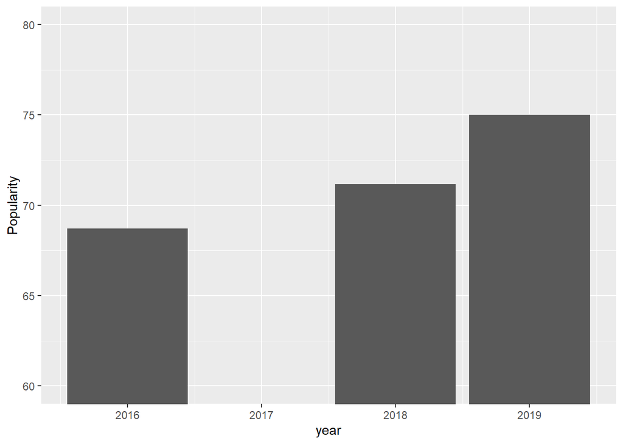

```r
ggplot(dat, aes(x = year, weight = popularity)) + geom_bar() + ylab('Popularity') + coord_cartesian(ylim=c(60, 80))
```

Post Malone has dropped 3 albums, the first in 2016, second in 2018, and the third in 2019, therefore those are the years he has a popularity value. It is clear that he is becoming more and more popular with each album that he releases.

**9.** What Genre is the most popular

```r
library(scales)
q9 <- by_genre %>%
   group_by(genres = genres) %>%
   summarise(popularity = mean(popularity)) %>%
   top_n(10, wt = popularity)%>%
   arrange(desc(popularity))

q9
```

```
## # A tibble: 10 x 2
##    genres             popularity
##    <chr>                   <dbl>
##  1 chinese electropop       79
##  2 korean mask singer       78
##  3 dutch rap pop            77
##  4 yaoi                     77
##  5 dong-yo                  76
##  6 rochester mn indie       76
##  7 afroswing                75.3
##  8 estonian pop             75
##  9 j-rap                    75
## 10 irish pop                74.6
```

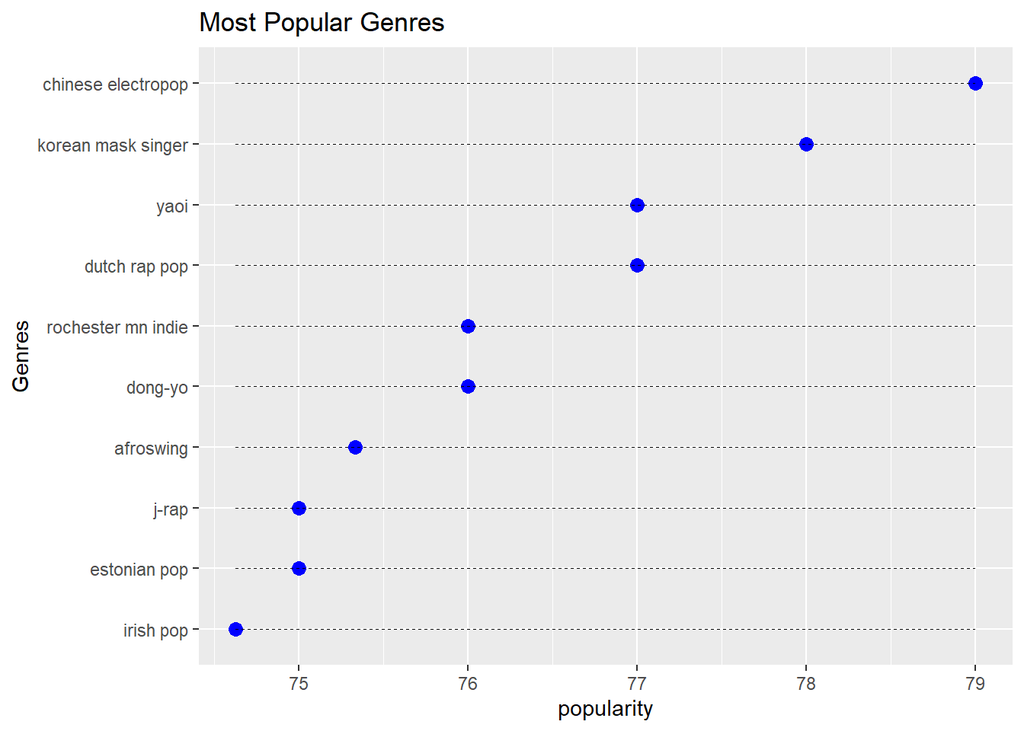

```r
ggplot(q9, aes(x=reorder(genres,popularity), y = popularity)) + geom_point(col="blue", size =3) +
   geom_segment(aes(x=genres,
                    xend = genres,
                    y = min(popularity),
                    yend = max(popularity)),
               linetype="dashed",
               size=.25) +
   labs(title = "Most Popular Genres", x='Genres') +
   coord_flip()
```

I found these genres quite surprising as the most popular. After further thought, it would make sense to see a Chinese favored genre as the most popular given they are the largest country in the world by population.